# Cyclistic Bike-Share Analysis

Nakshtra Saini

2024-12-11

## Problem Statement

Cyclistic, a bike-share company in Chicago, aims to maximize the number of annual memberships. This analysis focuses on understanding how casual riders and annual members use Cyclistic bikes differently. Insights will guide a marketing strategy to convert casual riders into annual members.

## Key Findings

- Differences between casual riders and annual members were analyzed.
- Visualizations reveal patterns in ride duration, bike usage, and temporal trends.
- Insights will help design targeted marketing strategies.

## Data Analysis and Visualization

### Total Rides by User Type

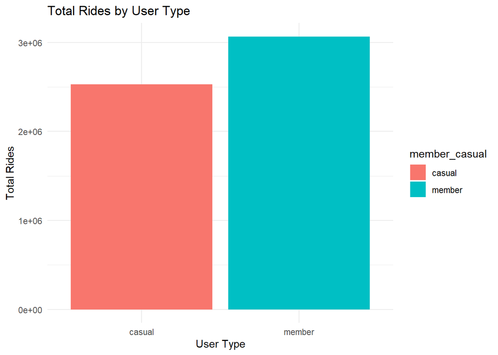

```r
all_data %>%
  group_by(member_casual) %>%
  summarise(total_rides = n()) %>%
  ggplot(aes(x = member_casual, y = total_rides, fill = member_casual)) +
  geom_bar(stat = "identity") +
  labs(title = "Total Rides by User Type", x = "User Type", y = "Total Rides") +
  theme_minimal()
```

### Average Ride Duration by User Type

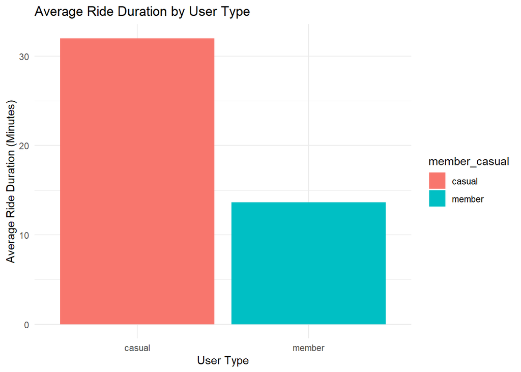

```r
all_data %>%
  group_by(member_casual) %>%
  summarise(avg_ride_length = mean(ride_length_numeric)) %>%
  ggplot(aes(x = member_casual, y = avg_ride_length, fill = member_casual)) +
  geom_bar(stat = "identity") +
  labs(title = "Average Ride Duration by User Type", x = "User Type", y = "Average Ride Duration (Minutes)") +
  theme_minimal()
```

### Rides by Month

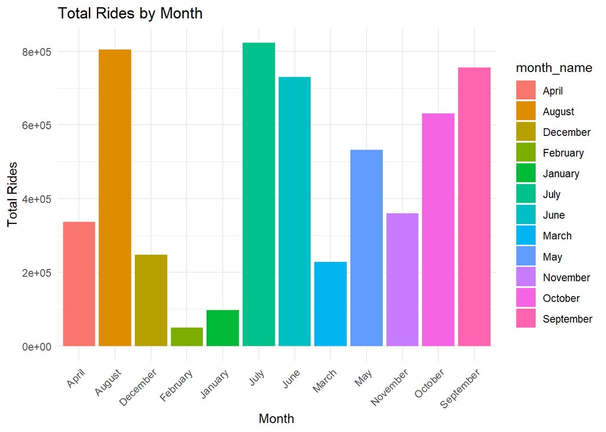

```r
all_data %>%
  mutate(month = month(started_at),       # Extract month as numeric value
         month_name = month.name[month]) %>%  # Map month numbers to month names
  group_by(month_name) %>%
  summarise(total_rides = n()) %>%
  ggplot(aes(x = month_name, y = total_rides, fill = month_name)) +
  geom_bar(stat = "identity") +
  labs(title = "Total Rides by Month", x = "Month", y = "Total Rides") +
  theme_minimal() +
  theme(axis.text.x = element_text(angle = 45, hjust = 1))  # Rotate x-axis labels for better readability
```

### Rides by Season

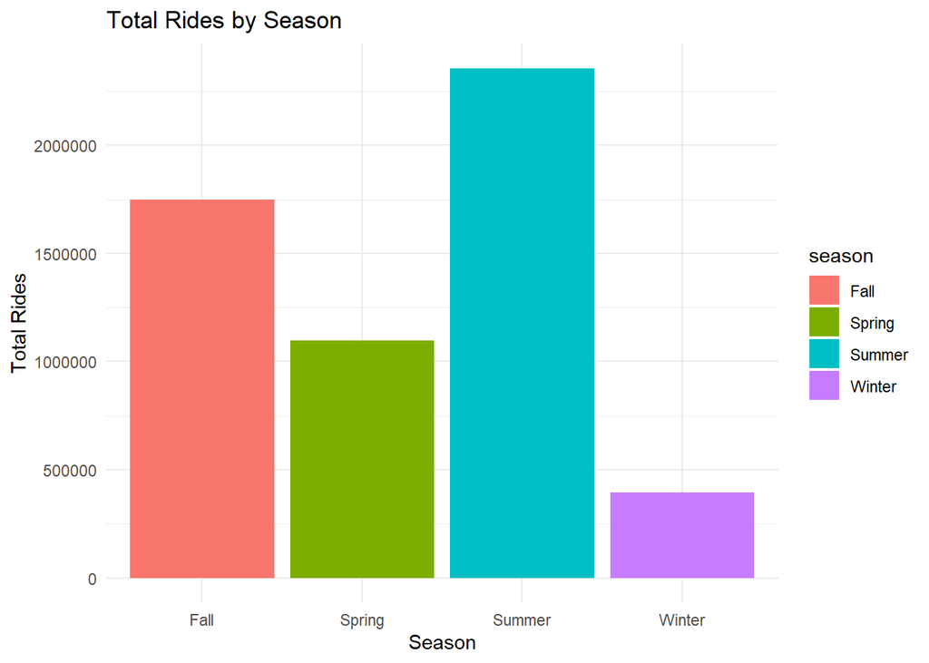

```r
all_data %>%
  mutate(season = case_when(
    month(started_at) %in% c(12, 1, 2) ~ "Winter",
    month(started_at) %in% c(3, 4, 5) ~ "Spring",
    month(started_at) %in% c(6, 7, 8) ~ "Summer",
    month(started_at) %in% c(9, 10, 11) ~ "Fall"
  )) %>%
  group_by(season) %>%
  summarise(total_rides = n()) %>%
  ggplot(aes(x = season, y = total_rides, fill = season)) +
  geom_bar(stat = "identity") +
  labs(title = "Total Rides by Season", x = "Season", y = "Total Rides") +
  theme_minimal()
```